# Single-cell Script Tutorial

Enrique de la Rosa Morón

16/09/2022

# Abstract

In this script we will show how to perform a general **Single-cell RNA-seq** data analysis.

Specifically, we are going to analyze **7643** cells from **healthy human bone marrow** and **peripheral blood** samples.

To know how to filter and doing subsetting, we are going to work with **CDs markers genes** and we will **delete erythrocytes** from our list.

# Data uploading, exploring and subsetting

Uploading needed packages

```r
library(Seurat)
library(RColorBrewer)
library(dplyr)
library(ggplot2)
library(scater)
library(TSCAN)
library(scran)
library(igraph)
col <- RColorBrewer::brewer.pal(20, "Set3")
```

The given raw matrix have already been filetered and it has the following structure: **genes in columns** and **cells in rows**.

```r
setwd("/home/enrique/CDs_project/dataset_1/")
matrix_single_cell <- read.csv("GSE149938_umi_matrix.csv.gz")
matrix_single_cell[c(2,500,650,790,1050,2000,3400,3600,4000,5000), c(2:15)]
```

|  | FO538757.3 | FO538757.2 | OR4F29 | OR4F16 | SAMD11 | NOC2L | KLHL17 | PLEKHN1 | PERM1 | HES4 | ISG15 | AGRN | RNF223 | C1orf159 |
| --- | --- | --- | --- | --- | --- | --- | --- | --- | --- | --- | --- | --- | --- | --- |
| BNK_spBM1_L1_bar26 | 0 | 0 | 0 | 0 | 0 | 0 | 0 | 0 | 0 | 0 | 0 | 0 | 0 | 0 |
| CD8T_tBM_L1_bar15 | 0 | 0 | 0 | 0 | 0 | 0 | 0 | 0 | 0 | 0 | 0 | 0 | 0 | 0 |
| CD8T_tPB_L5_bar68 | 0 | 0 | 0 | 0 | 0 | 0 | 0 | 0 | 0 | 0 | 0 | 0 | 0 | 0 |
| claM_moBM2_L11_bar56 | 0 | 0 | 0 | 0 | 0 | 0 | 0 | 0 | 0 | 0 | 0 | 0 | 0 | 0 |
| CLP_nkBM2_L4_bar22 | 0 | 0 | 0 | 0 | 0 | 0 | 0 | 0 | 0 | 0 | 0 | 0 | 0 | 0 |
| ery_eBM3_L8_bar57 | 0 | 0 | 0 | 0 | 0 | 0 | 0 | 0 | 0 | 0 | 0 | 0 | 0 | 0 |
| GMP_spBM3_L5_bar90 | 0 | 0 | 0 | 0 | 0 | 4 | 0 | 0 | 0 | 0 | 0 | 0 | 0 | 0 |
| hMDP_moBM1_L8_bar41 | 0 | 0 | 0 | 0 | 0 | 0 | 0 | 0 | 0 | 0 | 1 | 0 | 0 | 1 |
| immB_bBM1_L14_bar37 | 0 | 0 | 0 | 0 | 0 | 0 | 0 | 0 | 0 | 0 | 0 | 0 | 0 | 0 |
| MEP_spBM2_L5_bar76 | 0 | 0 | 0 | 0 | 0 | 0 | 0 | 0 | 0 | 0 | 1 | 0 | 0 | 0 |

As we work with *Seurat* package, we have to reorder cells in columns and genes in rows, meaning that we have to work with the transpose of our matrix.

```r
matrix_single_cell <- t(matrix_single_cell)
matrix_single_cell[c(2,500,650,790,1050,2000,3400,3600,4000,5000), c(2:13)]
```

```
##            BNK_spBM1_L1_bar26 BNK_spBM1_L1_bar27 BNK_spBM1_L1_bar28
## FO538757.3                  0                  0                  0
## THRAP3                      0                 31                  2
## KNCN                        0                  0                  0
## SRSF11                      3                 16                  0
## PTGFRN                      0                  0                  0
## GCSAML                      0                  0                  0
## SGOL1                       0                  4                  0
## CCDC71                      0                  0                  0
## H1FX                        0                 36                  5
## MAP9                        0                  0                  0
##            BNK_spBM1_L1_bar29 BNK_spBM1_L1_bar30 BNK_spBM1_L1_bar31
## FO538757.3                  0                  0                  0
## THRAP3                      5                  0                  9
## KNCN                        0                  0                  0
## SRSF11                     44                  1                  0
## PTGFRN                      0                  0                  0
## GCSAML                      0                  0                  0
## SGOL1                       0                  0                  0
## CCDC71                      0                  0                  0
## H1FX                        1                  1                  0
## MAP9                        0                  0                  0
##            BNK_spBM1_L1_bar32 BNK_spBM1_L1_bar33 BNK_spBM1_L1_bar35
## FO538757.3                  0                  0                  0
## THRAP3                     36                 38                 28
## KNCN                        0                  0                  0
## SRSF11                     12                 18                 15
## PTGFRN                      0                  0                  0
## GCSAML                      0                  0                  0
## SGOL1                       3                 10                  5
## CCDC71                      0                  0                  0
## H1FX                        0                  0                  0
## MAP9                        0                  0                  0
##            BNK_spBM1_L1_bar36 BNK_spBM1_L1_bar37 BNK_spBM1_L1_bar38
## FO538757.3                  0                  0                  0
## THRAP3                     20                 73                 68
## KNCN                        0                  0                  0
## SRSF11                      7                 30                 63
## PTGFRN                      0                  0                  0
## GCSAML                      0                  0                  0
## SGOL1                       0                 42                  8
## CCDC71                      0                  0                  0
## H1FX                        1                  5                  0
## MAP9                        0                  0                 18
```

## Exploring data matrix distribution

As usually happens in Single-cell data, we could see **lots of 0s** in our matrix

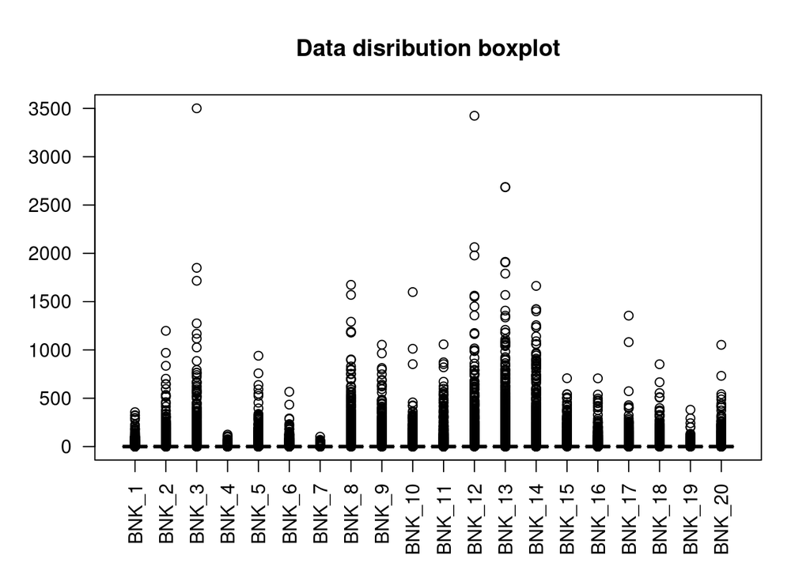

```r
boxplot(matrix_single_cell[,1:20], main= "Data disribution boxplot",
        names = c("BNK_1", "BNK_2", "BNK_3", "BNK_4", "BNK_5", "BNK_6", "BNK_7",
                  "BNK_8", "BNK_9", "BNK_10", "BNK_11", "BNK_12", "BNK_13",
                  "BNK_14", "BNK_15", "BNK_16", "BNK_17", "BNK_18", "BNK_19",
                  "BNK_20"), las=2, col = col, outline= T)
```

## Subset with CDs genes markers and deleting erythocytes

First, we have to upload the list with the currently known CDs, with **gene nomenclature name** and **CDs nomenclature** one.

```r
CD_gene_names <- read.delim2("/home/enrique/CD_gene_names.txt", header = F,
                             col.names = "CD_gene_names")
CD_gene_names <- CD_gene_names$CD_gene_names
CD_gene_names[1:30]
```

```
##  [1] "CD1A"   "CD1B"   "CD1C"   "CD1D"   "CD1E"   "CD2"    "CD3D"   "CD3E"
##  [9] "CD3G"   "CD4"    "CD5"    "CD6"    "CD7"    "CD8A"   "CD8B"   "CD9"
## [17] "MME"    "ITGAL"  "ITGAM"  "ITGAX"  "ITGAD"  "ANPEP"  "CD14"   "FCGR3A"
## [25] "FCGR3B" "ITGB2"  "CD19"   "MS4A1"  "CR2"    "CD22"
```

```r
CD_identifiers <- read.delim2("/home/enrique/CD_identifiers.txt", header = F,
                              col.names = "CD_identifiers")
CD_identifiers <- CD_identifiers$CD_identifiers
CD_identifiers[1:30]
```

```
##  [1] "CD1a"  "CD1b"  "CD1c"  "CD1d"  "CD1e"  "CD2"   "CD3d"  "CD3e"  "CD3g"
## [10] "CD4"   "CD5"   "CD6"   "CD7"   "CD8a"  "CD8b"  "CD9"   "CD10"  "CD11a"
## [19] "CD11b" "CD11c" "CD11d" "CD13"  "CD14"  "CD16a" "CD16b" "CD18"  "CD19"
## [28] "CD20"  "CD21"  "CD22"
```

Now, we will do the subset, building a matrix with our 369 CDs genes and specifically with **CDs nomenclature**.

```r
matrix_single_cell <- matrix_single_cell[CD_gene_names,]
matrix_single_cell_2 <- matrix_single_cell[match(CD_gene_names,
                                                 rownames(matrix_single_cell)),]
dim(matrix_single_cell_2)
```

```
## [1]  369 7643
```

```r
table(rownames(matrix_single_cell_2) %in% CD_gene_names)
```

```
##
## TRUE
##  369
```

```r
matrix_single_cell_3 <- cbind(rownames(matrix_single_cell_2), CD_identifiers,
                              matrix_single_cell_2)
rownames(matrix_single_cell_3) <- as.character(matrix_single_cell_3[,2])
rownames(matrix_single_cell_3)
```

```
##   [1] "CD1a"    "CD1b"    "CD1c"    "CD1d"    "CD1e"    "CD2"     "CD3d"
##   [8] "CD3e"    "CD3g"    "CD4"     "CD5"     "CD6"     "CD7"     "CD8a"
##  [15] "CD8b"    "CD9"     "CD10"    "CD11a"   "CD11b"   "CD11c"   "CD11d"
##  [22] "CD13"    "CD14"    "CD16a"   "CD16b"   "CD18"    "CD19"    "CD20"
##  [29] "CD21"    "CD22"    "CD23"    "CD25"    "CD26"    "CD27"    "CD28"
##  [36] "CD29"    "CD30"    "CD32a"   "CD32b"   "CD33"    "CD34"    "CD35"
##  [43] "CD36"    "CD37"    "CD38"    "CD39"    "CD40"    "CD41"    "CD42a"
##  [50] "CD42b"   "CD42c"   "CD42d"   "CD43"    "CD44"    "CD46"    "CD47"
##  [57] "CD48"    "CD49a"   "CD49b"   "CD49c"   "CD49d"   "CD49e"   "CD49f"
##  [64] "CD50"    "CD51"    "CD52"    "CD53"    "CD54"    "CD55"    "CD56"
##  [71] "CD58"    "CD59"    "CD61"    "CD62"    "CD62e"   "CD62l"   "CD63"
##  [78] "CD64"    "CD66a"   "CD66b"   "CD66c"   "CD66d"   "CD66e"   "CD66f"
##  [85] "CD68"    "CD69"    "CD70"    "CD71"    "CD72"    "CD73"    "CD74"
##  [92] "CD79a"   "CD79b"   "CD80"    "CD81"    "CD82"    "CD83"    "CD84"
##  [99] "CD85a"   "CD85c"   "CD85d"   "CD85f"   "CD85g"   "CD85h"   "CD85i"
```

[output cut: 38 more lines]

```r
dim(matrix_single_cell_3)
```

```
## [1]  369 7645
```

```r
matrix_single_cell_3 <- matrix_single_cell_3[,c(-1,-2)]
matrix_single_cell_3[c(2,17, 38, 178, 190, 237), c(2:7)]
```

```
##        BNK_spBM1_L1_bar26 BNK_spBM1_L1_bar27 BNK_spBM1_L1_bar28
## CD1b   "0"                "0"                "0"
## CD10   "25"               "3"                "1"
## CD32a  "0"                "0"                "0"
## CD157  "1"                "0"                "0"
## CD163b "0"                "0"                "0"
## CD215  "0"                "0"                "0"
##        BNK_spBM1_L1_bar29 BNK_spBM1_L1_bar30 BNK_spBM1_L1_bar31
## CD1b   "0"                "0"                "0"
## CD10   "28"               "61"               "0"
## CD32a  "0"                "0"                "0"
## CD157  "0"                "0"                "0"
## CD163b "0"                "0"                "0"
## CD215  "0"                "0"                "0"
```

We are going to work with *Seurat* package, so we are going to transform our matrix into a **Seurat object**.

```r
my_seurat_cds <- CreateSeuratObject(counts= matrix_single_cell_3)
my_seurat_cds
```

```
## An object of class Seurat
## 369 features across 7643 samples within 1 assay
## Active assay: RNA (369 features, 0 variable features)
```

Our data are supervised, so we know the cell type assigned by flow cytometry

```r
levels(my_seurat_cds@meta.data$orig.ident)
```

```
##  [1] "BNK"     "CD4T"    "CD8T"    "claM"    "CLP"     "cMOP"    "CMP"
##  [8] "ery"     "GMP"     "hMDP"    "HSC"     "immB"    "interM"  "kineNK"
## [15] "LMPP"    "matureN" "memB"    "MEP"     "metaN"   "MLP"     "MPP"
## [22] "myeN"    "naiB"    "NKP"     "nonM"    "plasma"  "preB"    "preM"
## [29] "proB"    "proN"    "regB"    "toxiNK"
```

As we indicated at the beggining, we will **delete erythrocytes** from our list to know how to filter and do subsetting.

```r
ery_cluster <- which(my_seurat_cds@meta.data$orig.ident == "ery")
ery_cells <- colnames(my_seurat_cds[,ery_cluster])
head(ery_cells)
```

```
## [1] "ery_eBM1_L1_bar1" "ery_eBM1_L1_bar2" "ery_eBM1_L1_bar3" "ery_eBM1_L1_bar4"
## [5] "ery_eBM1_L1_bar5" "ery_eBM1_L1_bar6"
```

```r
length(ery_cells)
```

```
## [1] 1747
```

```r
my_seurat_ne <- my_seurat_cds[,!colnames(my_seurat_cds) %in% ery_cells]
my_seurat_ne
```

```
## An object of class Seurat
## 369 features across 5896 samples within 1 assay
## Active assay: RNA (369 features, 0 variable features)
```

# Single-cell analysis protocol

## 1. Normalization

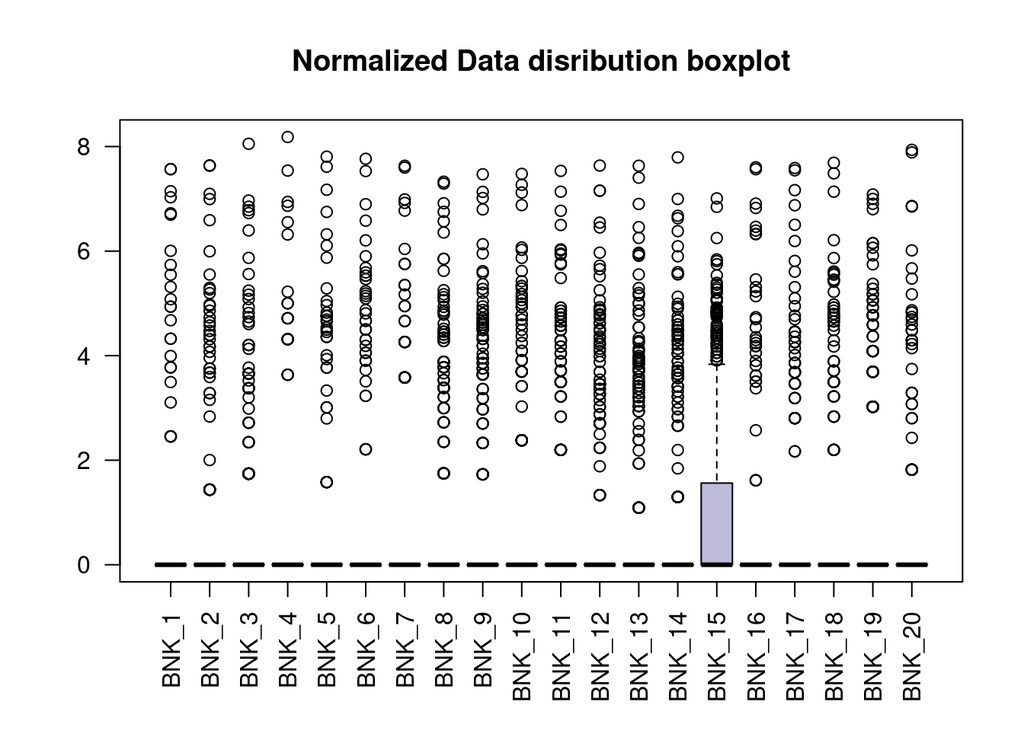

```r
my_seurat_ne <- NormalizeData(my_seurat_ne)
boxplot(as.matrix(my_seurat_ne@assays$RNA@data[,1:20]),
        main= "Normalized Data disribution boxplot",
        names = c("BNK_1", "BNK_2", "BNK_3", "BNK_4", "BNK_5", "BNK_6", "BNK_7", "BNK_8",
                  "BNK_9", "BNK_10", "BNK_11", "BNK_12", "BNK_13", "BNK_14", "BNK_15",
                  "BNK_16", "BNK_17", "BNK_18", "BNK_19", "BNK_20"),
        las=2, outline = T, col = col)
```

## 2. Scale Data

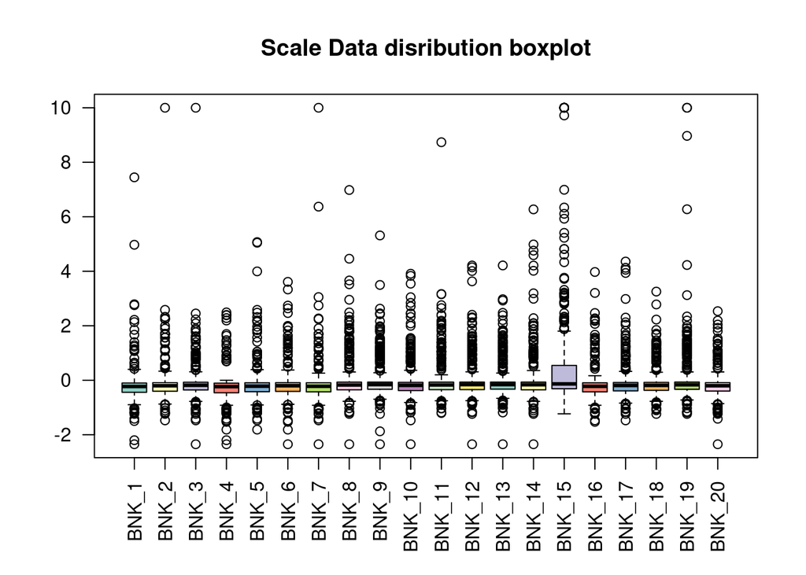

```r
my_seurat_ne <- ScaleData(my_seurat_ne, features = rownames(my_seurat_ne))
boxplot(as.matrix(my_seurat_ne@assays$RNA@scale.data[,1:20]),
        main= "Scale Data disribution boxplot", names = c("BNK_1", "BNK_2", "BNK_3",
        "BNK_4", "BNK_5", "BNK_6", "BNK_7", "BNK_8", "BNK_9", "BNK_10", "BNK_11",
        "BNK_12", "BNK_13", "BNK_14", "BNK_15", "BNK_16", "BNK_17", "BNK_18",
        "BNK_19", "BNK_20"), las=2, outline = T, col = col)
```

## 3. Dimensionality reduction and clustering analysis

### 3.1. Lineal dimensionality reduction (PCA) and determining the number of dimensions to work

–> PCA (Principal Component Analysis)

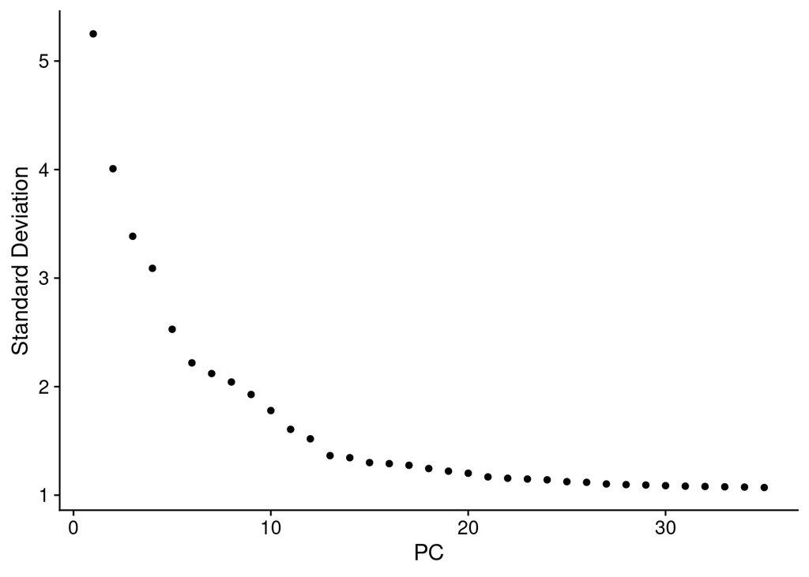

```r
my_seurat_ne <- FindVariableFeatures(my_seurat_ne, selection.method = "vst",
                                     nfeatures = 2000)
my_seurat_ne <- RunPCA(my_seurat_ne, features = VariableFeatures(object = my_seurat_ne))
ElbowPlot(my_seurat_ne, ndims = 35)
```

```r
e.var <- (my_seurat_ne@reductions$pca@stdev)^2/sum((my_seurat_ne@reductions$pca@stdev)^2)
cum.expl.var <- cumsum(e.var)
cum.expl.var
```

```
##  [1] 0.1909698 0.3022412 0.3816339 0.4477745 0.4920597 0.5261645 0.5573085
##  [8] 0.5862083 0.6119414 0.6338726 0.6517437 0.6677260 0.6806176 0.6931495
## [15] 0.7048534 0.7163881 0.7276522 0.7383954 0.7487228 0.7587297 0.7681781
## [22] 0.7774340 0.7865690 0.7955870 0.8043385 0.8129991 0.8214255 0.8297595
## [29] 0.8380373 0.8462275 0.8543504 0.8624279 0.8704614 0.8784526 0.8863897
## [36] 0.8942431 0.9020865 0.9098565 0.9175696 0.9252588 0.9329180 0.9405274
## [43] 0.9481130 0.9556239 0.9630751 0.9705092 0.9779189 0.9852997 0.9926540
## [50] 1.0000000
```

### 3.2. Clustering

```r
my_seurat_ne <- FindNeighbors(my_seurat_ne, dims = 1:30, do.plot = TRUE,
                              reduction = "pca")
my_seurat_ne <- FindClusters(my_seurat_ne, resolution = 1.2)
```

```
## Modularity Optimizer version 1.3.0 by Ludo Waltman and Nees Jan van Eck
##
## Number of nodes: 5896
## Number of edges: 273386
##
## Running Louvain algorithm...
## Maximum modularity in 10 random starts: 0.8620
## Number of communities: 19
## Elapsed time: 0 seconds
```

### 3.3. Non-Lineal dimensionality reduction (t-SNE) and its representation

–> t-SNE (t-distributed Stochastic Neighbor Embedding )

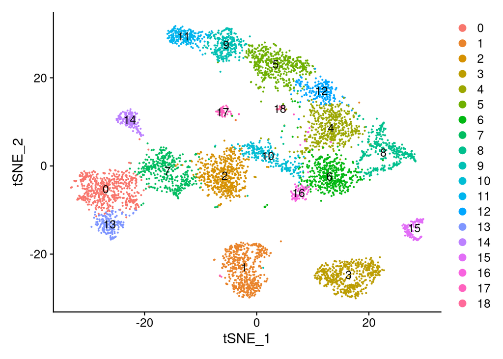

```r
my_seurat_ne <- RunTSNE(my_seurat_ne, dims = 1:30, perplexity = 60)
DimPlot(my_seurat_ne, reduction = "tsne", label = my_seurat_ne@meta.data$seurat_clusters)
```

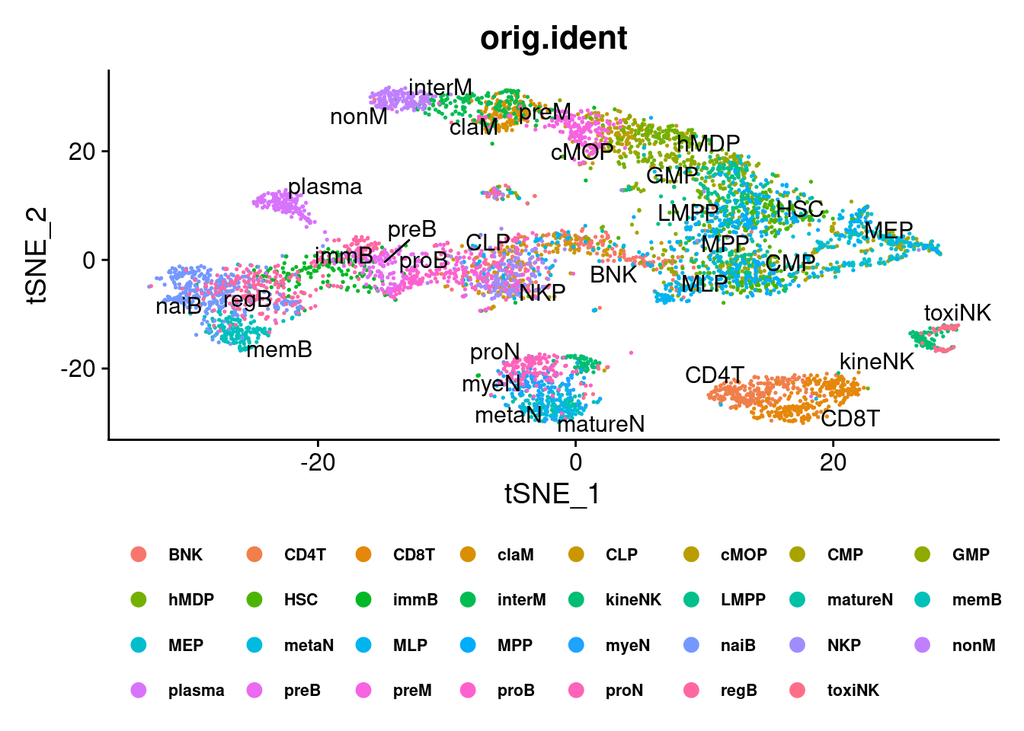

```r
plot2<-DimPlot(my_seurat_ne, reduction = "tsne", group.by = 'orig.ident', label = my_seurat_ne@meta.data$orig.ident, repel = T)
plot2 +theme(legend.position="bottom")+ theme(legend.text =element_text(colour="black", size=8, face="bold")) +
guides(color = guide_legend(override.aes = list(size=3), nrow=4, byrow = T))
```

## 4. Find differentially expressed genes

```r
my_markers_ne <- FindAllMarkers(my_seurat_ne, only.pos = TRUE, min.diff.pct = 0.2,
                                 logfc.threshold = 0.25)
my_tibble_ne <- my_markers_ne %>% group_by(cluster) %>% top_n(n = 30, wt = avg_log2FC)
diff_ne <- (my_tibble_ne$pct.1 - my_tibble_ne$pct.2)
my_tibble_df_ne <- cbind(my_tibble_ne, diff_ne)
head(my_tibble_df_ne)
```

| p_val | avg_log2FC | pct.1 | pct.2 | p_val_adj | cluster | gene | ...8 |
| --- | --- | --- | --- | --- | --- | --- | --- |
| 0.00000e+00 | 5.050477 | 0.803 | 0.066 | 0.000000e+00 | 0 | CD23 | 0.737 |
| 0.00000e+00 | 3.678931 | 0.995 | 0.143 | 0.000000e+00 | 0 | CD20 | 0.852 |
| 0.00000e+00 | 3.580851 | 0.900 | 0.126 | 0.000000e+00 | 0 | CD307a | 0.774 |
| 0.00000e+00 | 3.240995 | 0.775 | 0.118 | 0.000000e+00 | 0 | CD268 | 0.657 |
| 0.00000e+00 | 3.049046 | 0.705 | 0.099 | 0.000000e+00 | 0 | CD307b | 0.606 |
| 1.44939e-295 | 2.838416 | 0.895 | 0.219 | 5.348249e-293 | 0 | CD22 | 0.676 |

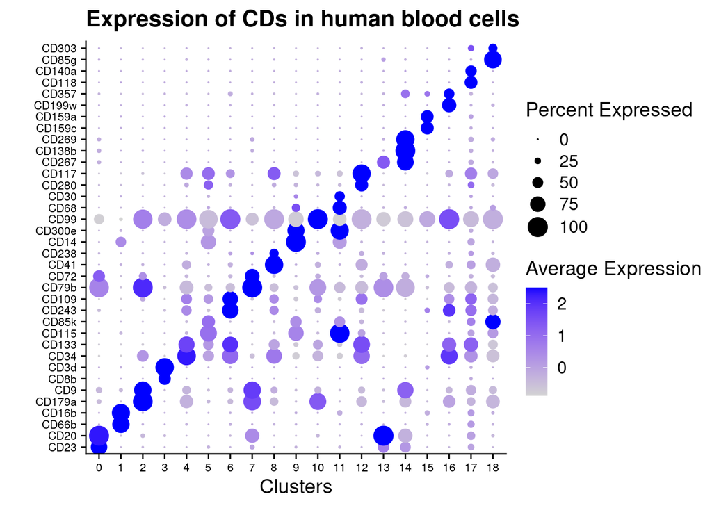

```r
topgenes <- c()
for(i in levels(my_tibble_ne$cluster)){
  topgenes <- c(topgenes, my_tibble_ne$gene[my_tibble_ne$cluster %in% i][1:2])
  }

Idents(my_seurat_ne) <- "orig.ident"
DotPlot(my_seurat_ne, features = unique(topgenes), group.by = 'seurat_clusters') +
  coord_flip() +
  ggtitle ("Expression of CDs in human blood cells") + ylab("Clusters") + xlab("") +
 theme(axis.text=element_text(size=8))
```

–> We detect some small and controversial clusters, so we filtered them out

```r
cluster_16_ne <- which(my_seurat_ne@meta.data$seurat_clusters == 16)
cluster_16_cells <- colnames(my_seurat_ne[,cluster_16_ne])
my_seurat_16 <- my_seurat_ne[,!colnames(my_seurat_ne) %in% cluster_16_cells]


cluster_17_ne <- which(my_seurat_16@meta.data$seurat_clusters == 17)
cluster_17_cells <- colnames(my_seurat_16[,cluster_17_ne])
my_seurat_17 <- my_seurat_16[,!colnames(my_seurat_16) %in% cluster_17_cells]


cluster_18_ne <- which(my_seurat_17@meta.data$seurat_clusters == 18)
cluster_18_cells <- colnames(my_seurat_17[,cluster_18_ne])
my_seurat_18 <- my_seurat_17[,!colnames(my_seurat_17) %in% cluster_18_cells]
my_seurat_ne <- my_seurat_18
```

## 5. Trajectory analysis

Finally, as we have many progenitors, intermediate and mature cells, we can do a trajectory analysis reflecting the maturation pathway of our blood/bone marrow cells.

```r
new_sce <- as.SingleCellExperiment(my_seurat_ne)
new_sce
```

```
## class: SingleCellExperiment
## dim: 369 5725
## metadata(0):
## assays(3): counts logcounts scaledata
## rownames(369): CD1a CD1b ... CD362 CD363
## rowData names(0):
## colnames(5725): BNK_spBM1_L1_bar25 BNK_spBM1_L1_bar26 ...
##   toxiNK_nkPB2_L12_bar32 toxiNK_nkPB2_L12_bar33
## colData names(6): orig.ident nCount_RNA ... seurat_clusters ident
## reducedDimNames(2): PCA TSNE
## altExpNames(0):
```

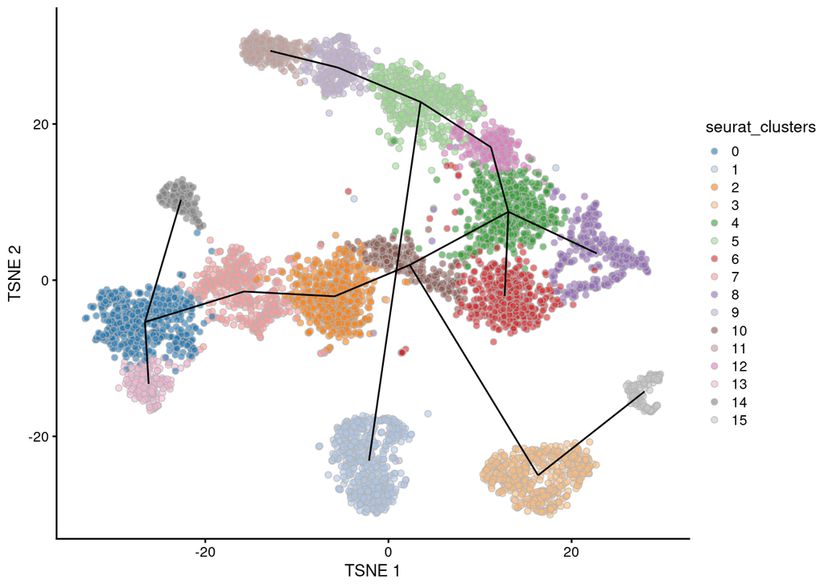

```r
new_sce@colData$seurat_clusters <- droplevels(new_sce@colData$seurat_clusters)
clusters_factor <- as.factor(new_sce@colData$seurat_clusters)
by.cluster <- aggregateAcrossCells(new_sce, ids = clusters_factor)
centroids <- reducedDim(by.cluster, "PCA")
mst_1 <- TSCAN::createClusterMST(centroids, clusters = NULL)
line.data <- reportEdges(by.cluster, mst=mst_1, clusters=NULL, use.dimred="TSNE")
plotTSNE(new_sce, colour_by="seurat_clusters") + geom_line(data=line.data,
         mapping=aes(x=tSNE_1, y=tSNE_2, group=edge), inherit.aes = FALSE)
```

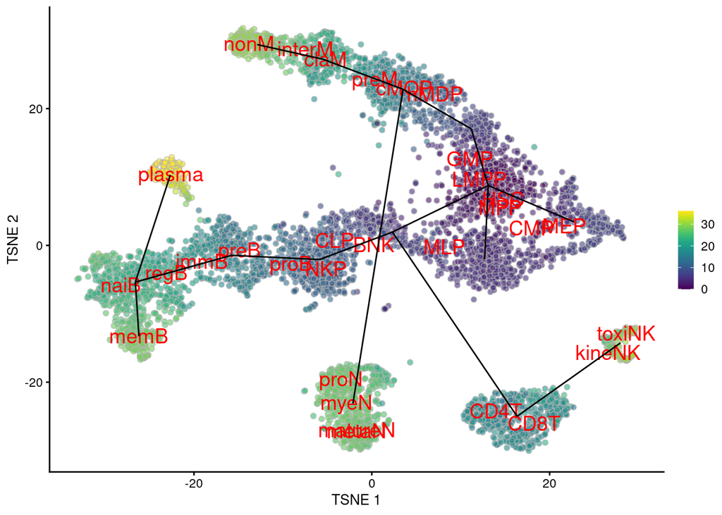

```r
colLabels(new_sce) <- new_sce@colData$seurat_clusters
map.tscan <- mapCellsToEdges(new_sce, mst=mst_1, use.dimred="PCA")
tscan.pseudo <- orderCells(map.tscan, mst_1, start = "4")
common.pseudo <- rowMeans(tscan.pseudo, na.rm=TRUE)
plotTSNE(new_sce, colour_by=I(common.pseudo),
         text_by="ident", text_colour="red") +
  geom_line(data=line.data,
            mapping=aes(x=tSNE_1, y=tSNE_2, group=edge))
```